# Darwin’s finches: Intraspecific morphological variation

Kirsten Hendricks

2025-03-18

# Methods

### Sampling:

The first step is to fetch the data, and rename the species for readability.

The data is then grouped by Species and the columns are labelled according to the traits being expressed by the each variable. The first, second and third statistical moments of each variable are then taken (those being the mean, standard deviation and variance respectively).

```r
finch_smry <- fin2 %>%
  group_by(Species) %>%
  dplyr::summarize(across(
    where(is.numeric),
    list(
      mean = ~ round(mean(., na.rm = TRUE), 3),
      sd = ~ round(sd(., na.rm = TRUE), 3),
      var = ~ round(var(., na.rm = TRUE), 3)
    ),
    .names = "{.col}_{.fn}"
  )) %>%
  pivot_longer(
    cols = -Species,
    names_to = c("Trait", ".value"),
    names_sep = "_"
  ) %>%
  mutate(Mean_SD = paste(mean, "±", sd)) %>%
  dplyr::select(-mean, -sd) %>%
  pivot_wider(
    id_cols = Species,
    names_from = Trait,
    values_from = c(Mean_SD, var),
    names_glue = "{Trait}_{.value}"
  ) %>%
  dplyr::select(  ##Reordering the columns such that the mean trait (± Std Dev) is directly adjascent to the trait varience. This means the readers' eyes do not need to scan back and forth across the whole table to find the variance of the "Upper Beak Length" (as an example), it is placed the row directly to the right of the mean and std dev row.
    Species,
    BodyL_Mean_SD,
    BodyL_var,
    WingL_Mean_SD, #Trait mean is ordered next to its matching trait variance
    WingL_var,
    TailL_Mean_SD,#................
    TailL_var,
    BeakW_Mean_SD,#..........................
    BeakW_var,
    BeakH_Mean_SD,#..................
    BeakH_var,
    LBeakL_Mean_SD,#................
    LBeakL_var,
    UBeakL_Mean_SD,#...................
    UBeakL_var,
    `N.UBkL_Mean_SD`,#...........................
    `N.UBkL_var`,
    TarsusL_Mean_SD,#...................
    TarsusL_var
  )
```

The following is a summary table denoting the different species of Finches, along with the means, ± the standard deviations and the variance of each variable.

| Species | avg Body Length (± sd) | BL var | avg Wing Length (± sd) | WL var | avg Tail Length (± sd) | TL var | avg Beak Width (± sd) | BW var | avg Beak Height (± sd) | BH var | avg L.Beak Length (± sd) | LBL var | avg U. Beak Length (± sd) | UBL var | N to U. Beak Length (± sd) | NUBKL var | avg Tarsus Length (± sd) | TarsusL var |
| --- | --- | --- | --- | --- | --- | --- | --- | --- | --- | --- | --- | --- | --- | --- | --- | --- | --- | --- |
| G. f. fortis | 128.136 ± 7.996 | 63.933 | 69.432 ± 3.325 | 11.055 | 43.023 ± 4.291 | 18.416 | 9.468 ± 0.777 | 0.604 | 12.723 ± 1.075 | 1.156 | 8.873 ± 0.596 | 0.355 | 17.118 ± 1.04 | 1.082 | 11.568 ± 0.75 | 0.563 | 21.1 ± 0.991 | 0.982 |
| G. f. parvula | 115.235 ± 5.334 | 28.457 | 62.296 ± 1.998 | 3.992 | 40.454 ± 3.009 | 9.057 | 6.731 ± 0.33 | 0.109 | 8.602 ± 0.476 | 0.226 | 6.527 ± 0.352 | 0.124 | 12.736 ± 0.54 | 0.292 | 8.204 ± 0.415 | 0.172 | 18.898 ± 0.753 | 0.567 |
| G. f. platyrhyncha | 139.818 ± 7.998 | 63.964 | 73.318 ± 2.714 | 7.364 | 44.409 ± 2.998 | 8.991 | 10.709 ± 1.494 | 2.231 | 14.3 ± 1.594 | 2.540 | 9.409 ± 0.767 | 0.589 | 17.791 ± 1.01 | 1.021 | 12.309 ± 0.913 | 0.833 | 21.791 ± 0.511 | 0.261 |
| G. heliobates | 127.789 ± 7.254 | 52.620 | 70.395 ± 1.838 | 3.377 | 44.711 ± 3.172 | 10.064 | 6.737 ± 0.277 | 0.077 | 8.337 ± 0.476 | 0.227 | 8.042 ± 0.389 | 0.151 | 15.005 ± 0.327 | 0.107 | 10.279 ± 0.488 | 0.238 | 21.789 ± 0.758 | 0.574 |
| G.p. prosthemelas | 113.308 ± 3.473 | 12.064 | 61.077 ± 1.427 | 2.035 | 38.923 ± 2.95 | 8.702 | 6.262 ± 0.307 | 0.094 | 7.962 ± 0.493 | 0.243 | 5.562 ± 0.233 | 0.054 | 11.115 ± 0.434 | 0.188 | 7.077 ± 0.344 | 0.119 | 19.977 ± 0.611 | 0.374 |

### Data Analysis

MANOVA:

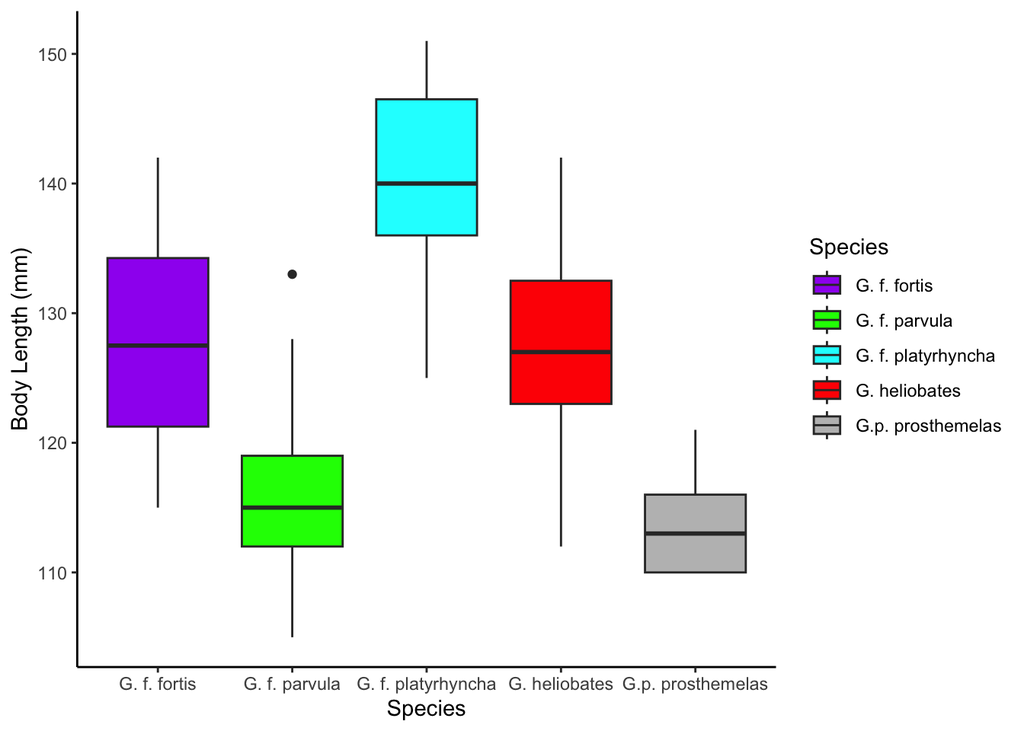

```r
##Creating a List to assign Species Colours Once and for all

species_colors <- c(
  "G. heliobates" = "red",
  "G.p. prosthemelas" = "grey",
  "G. f. parvula" = "green",
  "G. f. fortis" = "purple",
  "G. f. platyrhyncha" = "cyan"
)

##Box Plots for comparing Body Lengths of the species

ggplot2::ggplot(data= fin2, aes(x = Species, y = BodyL, fill = Species)) +
  geom_boxplot() +
  scale_fill_manual(values = species_colors) +
  xlab("Species") +
  ylab("Body Length (mm)") +
  theme_classic() +
  #facet_wrap(~Species) +
  guides(fill = guide_legend(title = "Species"))
```

```r
# Using data.frame 'fin2' and the morphological variables therein:

# we perform the MANOVA on the data, grouped by species

depvar <- cbind(fin2$BodyL, fin2$WingL, fin2$TailL, fin2$BeakW, fin2$BeakH, fin2$LBeakL, fin2$UBeakL, fin2$N.UBkL, fin2$TarsusL)

manova_model <- manova(depvar ~ Species, data = fin2)
print(manova_model)
```

```
## Call:
##    manova(depvar ~ Species, data = fin2)
##
## Terms:
##                  Species Residuals
## resp 1          9315.796  5350.698
## resp 2          2535.198   710.386
## resp 3           514.368  1486.750
## resp 4           276.025    46.245
## resp 5           603.114    74.773
## resp 6           200.268    26.650
## resp 7           628.060    60.454
## resp 8           390.814    39.640
## resp 9           220.263    83.410
## Deg. of Freedom        4       141
##
## Residual standard errors: 6.160212 2.244592 3.247202 0.572692 0.728221 0.4347499 0.6547935 0.5302238 0.7691276
## Estimated effects may be unbalanced
```

```r
# print and summarise the results


summary(manova_model)
```

```
##            Df Pillai approx F num Df den Df    Pr(>F)
## Species     4  2.385   22.316     36    544 < 2.2e-16 ***
## Residuals 141
## ---
## Signif. codes:  0 '***' 0.001 '**' 0.01 '*' 0.05 '.' 0.1 ' ' 1
```

```r
eta_squared(manova_model)
```

```
## # Effect Size for ANOVA (Type I)
##
## Parameter | Eta2 (partial) |       95% CI
## -----------------------------------------
## Species   |           0.60 | [0.54, 1.00]
##
## - One-sided CIs: upper bound fixed at [1.00].
```

PCA

```r
      # Let's first check whether there are any NA values
      any(is.na(fin2))
```

```
## [1] FALSE
```

```r
      FinchData = na.omit(fin2)


      # remove non-numeric columns from the dataframe (Species and sex)
      FinchDataclean = FinchData %>%
        dplyr::select(where(is.numeric))

      # scaling the data
      pca_fit <- FinchDataclean %>%
        prcomp(scale = TRUE)

      # PCA summary results
      summary(pca_fit)
```

```
## Importance of components:
##                           PC1     PC2     PC3     PC4     PC5     PC6     PC7
## Standard deviation     2.6154 0.93154 0.73027 0.56506 0.45724 0.35458 0.20024
## Proportion of Variance 0.7601 0.09642 0.05926 0.03548 0.02323 0.01397 0.00446
## Cumulative Proportion  0.7601 0.85648 0.91573 0.95121 0.97444 0.98841 0.99286
##                            PC8     PC9
## Standard deviation     0.19315 0.16410
## Proportion of Variance 0.00415 0.00299
## Cumulative Proportion  0.99701 1.00000
```

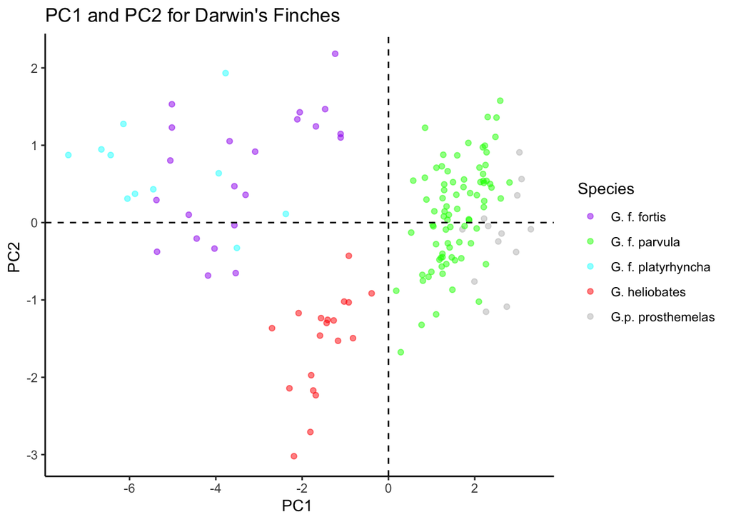

```r
      #loadings
      pca_loadings = pca_fit$rotation %>%
        as.data.frame() %>%
        dplyr::select(c(PC1, PC2))


      # Collecting the PC scores
      pca_fit_df = pca_fit$x %>%
        as.data.frame() %>%
        dplyr::select(c(PC1, PC2)) #To focus on the first 2 principle components


      # Add "Species" column to the end of pca_fit_df dataframe
      pca_fit_df$Species = FinchData$Species

      # change the alpha value to add transparency to the colours
      pca_plot = pca_fit_df %>%
        ggplot(aes(PC1, PC2, color = Species)) +
        geom_point(size = 1.5, alpha = 0.5) +
        scale_color_manual(
          values = species_colors
        ) +
        xlab("PC1 ") +
        ylab("PC2 ") +
        labs(color = "Species",
             title = "PC1 and PC2 for Darwin's Finches ") +
        # add lines through the origin
        geom_hline(yintercept = 0, linetype = "dashed", color = "black") +
        geom_vline(xintercept = 0, linetype = "dashed", color = "black") +
        theme_classic()

      pca_plot
```

LDA:

```r
# Select the relevant columns for LDA
lda_data <- fin2[, c("Species", "BodyL", "WingL", "TailL", "BeakW", "BeakH", "LBeakL", "UBeakL", "N.UBkL", "TarsusL")]

# Perform LDA
lda_result <- lda(Species ~ ., data = lda_data)

lda_df <- lda_result$scaling %>%
  as.data.frame()%>%
  dplyr::select(c(LD1, LD2, LD3, LD4))

  gt(lda_df,
  rowid_to_column(lda_df)%>% head(),
  rowname_col = "Traits",
  caption = ""



)
```

| LD1 | LD2 | LD3 | LD4 |
| --- | --- | --- | --- |
| 0.006624022 | 0.02196254 | -0.04836791 | -0.09807236 |
| -0.040350663 | 0.24160032 | -0.01694377 | -0.19286618 |
| 0.080743429 | 0.03713117 | 0.03483608 | -0.05335578 |
| 0.514485991 | -1.11246200 | -0.35712070 | -1.04816553 |
| -0.563617800 | -1.10631291 | -0.47528447 | 0.53983532 |
| -0.179570088 | 0.45541956 | 0.80201104 | -0.82530815 |
| -0.863182237 | -0.03293624 | 1.14800351 | 0.65687938 |
| -0.811443884 | 0.90377751 | -0.26145854 | 0.52886993 |
| 0.049108054 | 0.41524382 | -1.20818210 | 0.65767142 |